# Assignment 5

Timo Suter

2023-03-30

```r
setwd("C:/Users/Timo/OneDrive - Max Suter/Dokumente/Studium/Master/2. Semester/Bioinformatic Approaches to Regulatory Genomics and Epigenomics/Week 5")
```

```r
suppressPackageStartupMessages({
  library(AnnotationHub)
  library(ensembldb)
  library(GenomicRanges)
  library(epiwraps)
  library(rtracklayer)
  library(ggplot2)
})
ah <- AnnotationHub(localHub=TRUE)
```

```
## Using 'localHub=TRUE'
##   If offline, please also see BiocManager vignette section on offline use
```

```
## snapshotDate(): 2023-03-21
```

#identify bivalent domains for H3K27me3 and H3K4me3 in mESC ##download H3K4me3 and H3K27me3 data (from last week)

```r
download.file("https://www.encodeproject.org/files/ENCFF247GVM/@@download/ENCFF247GVM.bed.gz",dest="H3K4me3.bed.gz")
H3K4me3 <- rtracklayer::import("H3K4me3.bed.gz", format="narrowPeak")
download.file("https://www.encodeproject.org/files/ENCFF008XKX/@@download/ENCFF008XKX.bed.gz",dest="H3K27me3.bed.gz")
H3K27me3 <- rtracklayer::import("H3K27me3.bed.gz", format="narrowPeak")
```

##identify bivalent domains

```r
bido_mesc <- H3K4me3[overlapsAny(H3K4me3, H3K27me3)]
length(bido_mesc)
```

```
## [1] 3219
```

3219 domains of H3K4me3 are bivalent with H3K27me3 peaks in mESC

#change upon differentiation into hepatocytes ##download data

```r
download.file("https://www.encodeproject.org/files/ENCFF625DES/@@download/ENCFF625DES.bed.gz",dest="H3K4me3_hep.bed.gz")
H3K4me3_hep <- rtracklayer::import("H3K4me3_hep.bed.gz", format="narrowPeak")
download.file("https://www.encodeproject.org/files/ENCFF581ZRF/@@download/ENCFF581ZRF.bed.gz", dest = "H3K27me3_hep.bed.gz")
H3K27me3_hep <- rtracklayer::import("H3K27me3_hep.bed.gz", format="narrowPeak")
```

#number of overlaps between hepatocytic H3K4me3 / H3K27me3 and mESCs

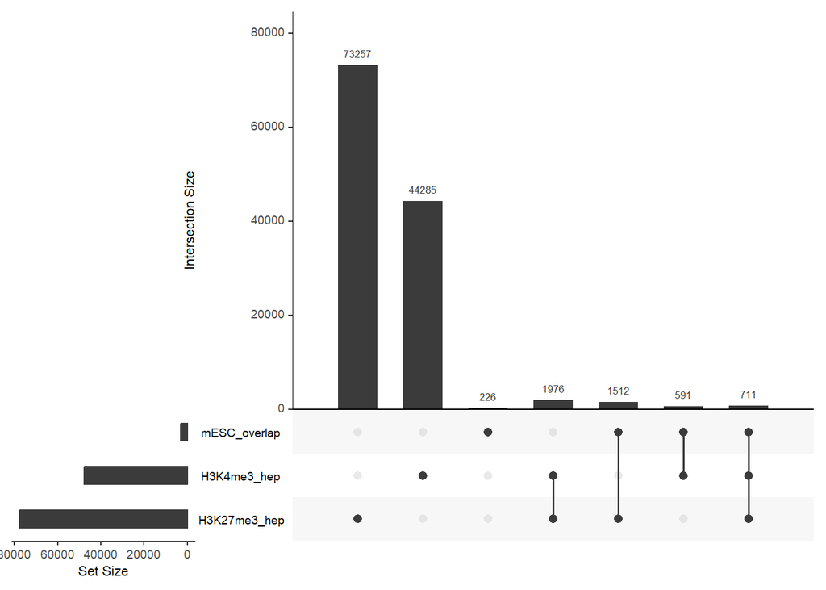

```r
overlaps <- list(bido_mesc, H3K27me3_hep, H3K4me3_hep)
names(overlaps) <- c("mESC_overlap", "H3K27me3_hep", "H3K4me3_hep")
regionUpset(overlaps[c(1,2,3)])
```